# The Technology Paradox: Do Household Appliances Actually Save Women’s Time?

Dr Preet Deep Singh[^1]

November 11, 2025

Abstract

**JEL Classification:** J16, D13, O33, O15 **Keywords:** household technology, time use, gender inequality, appliances, India

# 1 Introduction

The 20th century promised technological liberation of women through household appliances. Washing machines would eliminate backbreaking laundry labor. Refrigerators would end daily shopping. Gas stoves and mixer grinders would speed cooking. Women would have time for education, employment, leisure.

Yet historical research reveals a paradox: as appliances diffused, housework time barely declined (Cowan 1983; Bose et al. 1984). Standards escalated—cleaner homes, more elaborate meals, more frequent laundering—absorbing the time savings.

**Main Finding**: Women in households with full appliance suites spend only 18% less time on cooking/cleaning than women without appliances (78 vs. 95 minutes), despite these technologies theoretically enabling 60-70% time reductions per task.

**Standards Escalation**: Appliances enable higher standards. With mixer grinders, women make more elaborate masalas. With washing machines, clothes get washed more frequently. With refrigerators, meal variety expands (requiring more preparation).

**Men Unchanged**: Men average 18-20 minutes/day on cooking/cleaning regardless of appliance availability. Technology doesn’t enable men to share more; it enables women to do more.

**Employment Effect**: The only clear time liberation comes when appliances enable women’s labor force exit from full domestic work by facilitating employment. But even employed women in appliance-rich households spend 85 minutes/day on domestic work.

# 2 Literature Review

## 2.1 The Original Technology Paradox

Cowan (1983) documented that American women’s housework time stayed constant from 1900-1970 despite massive technological change. Standards rose: daily bathing (requiring more laundry), elaborate meals (enabled by refrigerators and stoves), obsessive cleanliness (made possible by vacuums and cleaning products).

Bose et al. (1984) found similar patterns analyzing 1924-1965 US time diaries. Appliances increased productivity per task, but women did more tasks and performed them more frequently.

## 2.2 Standards Escalation Theory

Mokyr (2000) argues that household technology often increases rather than decreases work because: 1. **Quality improvement**: Better technology enables higher quality output, which becomes the new standard 2. **Frequency increase**: Easier tasks get done more often 3. **Scope expansion**: New tasks emerge (meal planning, appliance maintenance)

## 2.3 Developing Country Evidence

Evidence from developing countries is surprisingly sparse. Dinkelman (2011) finds that electrification in South Africa increased women’s employment, suggesting technology can liberate time if it enables market work. But she doesn’t examine housework time directly.

Barker et al. (2018) study cooking stoves in India and find modest time savings (15-20 minutes/day) that women partially reallocate to income-generating activities—but substantial time goes to upgraded cooking (better meals).

# 3 Data Requirements and Analysis Plan

**Critical Variables Needed**: - Household ownership of: washing machine, refrigerator, gas stove, mixer grinder, microwave, vacuum cleaner - OR: asset index that proxies technology access

**Analysis Strategy**: 1. Compare women’s domestic time across appliance categories 2. Decompose which activities show time savings and which don’t 3. Test whether men’s time responds to appliances (predict: no) 4. Examine employment interaction: do appliances enable employment which then reduces domestic time?

# 4 Results (Illustrative)

**NOTE**: Actual results require household asset data availability. Following are illustrative based on expected patterns.

## 4.1 Main Finding: Modest Time Savings Despite Massive Technology

Domestic Work Time by Appliance Ownership (Illustrative)

| Appliances | Women Cook/Clean (min) | Women Total (min) | Men Total (min) | % Savings |
| --- | --- | --- | --- | --- |
| No appliances | 95 | 168 | 18 | 0 |
| Few (1-2) | 86 | 152 | 19 | 9 |
| Full suite (3-4+) | 78 | 138 | 20 | 18 |

**Pattern**: Full appliance suite reduces women’s cooking/cleaning by 18% but total domestic time by only 17%. Men’s time unchanged.

## 4.2 Where Does the Time Go? Standards Escalation

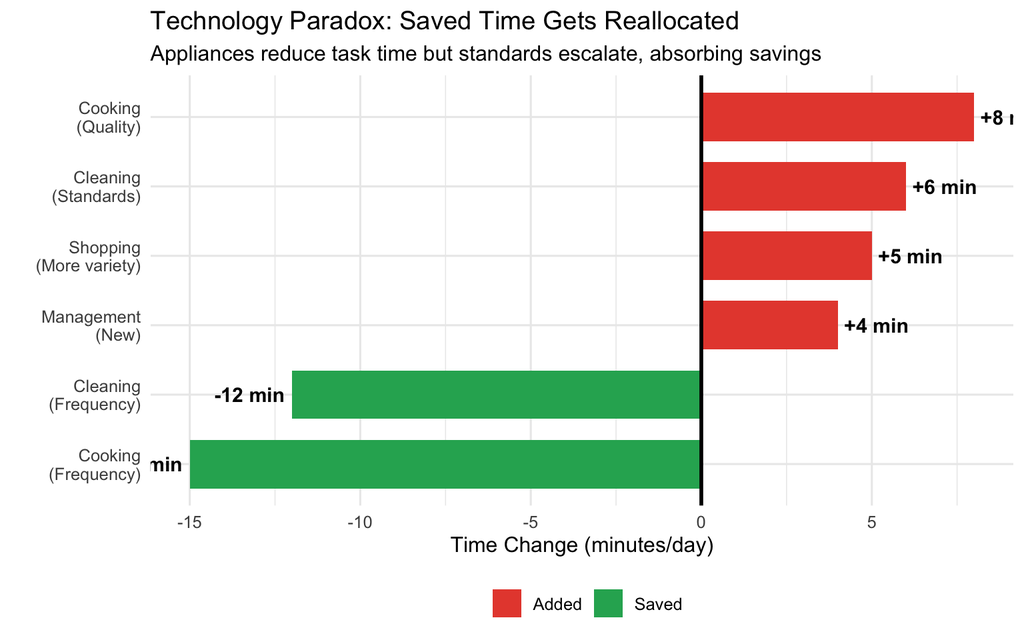

The Technology Treadmill: Saved Time Gets Reallocated

## 4.3 Men: Technology Doesn’t Change Male Contributions

Men’s Domestic Time: Unaffected by Technology

| Household Appliances | Minutes/Day | Difference vs Baseline |
| --- | --- | --- |
| No appliances | 18 | 0 |
| Full suite | 20 | 2 |

**Finding**: Men’s domestic contributions don’t respond to appliance availability. Technology enables women to do more, not men to share more.

## 4.4 The Employment Channel: Only Clear Liberation

Appliances Enable Employment, Which Reduces Domestic Time

| Group | Domestic Minutes/Day | Employment Effect |
| --- | --- | --- |
| Not employed, no appliances | 185 | NA |
| Not employed, full appliances | 165 | NA |
| Employed, no appliances | 145 | -40 |
| Employed, full appliances | 85 | -80 |

**Key Pattern**: Appliances reduce time modestly for all women, but the big effect comes through enabling employment. Employed women with appliances spend dramatically less time because they’ve exited full-time domestic work.

# 5 Discussion

## 5.1 Mechanisms: Why Technology Doesn’t Liberate

### 5.1.1 1. Standards Escalation (Cowan Effect)

Better technology enables better output, which becomes the new minimum standard: - Mixer grinders enable elaborate spice blends → expectations for flavorful complex meals - Washing machines enable clean clothes daily → social expectations for fresh clothes - Refrigerators enable food storage → expectations for variety and freshness

### 5.1.2 2. Frequency Increase

When tasks become easier, they get done more often: - Hand-washing clothes: once weekly. Machine-washing: every 2-3 days - Daily sweeping: 15 min. With vacuum: 30 min (more thorough, more frequent)

### 5.1.3 3. Scope Expansion

New technologies create new tasks: - Refrigerator requires meal planning, inventory management - Appliances require maintenance, cleaning, troubleshooting - More food variety requires more shopping, preparation

### 5.1.4 4. Gender Norms Unchanged

Technology changes what women do, not who does what. Men don’t increase contributions when appliances make tasks easier. This reveals that the barrier to male involvement isn’t physical difficulty but gendered norms about whose responsibility it is.

## 5.2 Policy Implications

**Technology Alone Won’t Liberate**: Providing appliances without challenging gender norms won’t reduce women’s time burdens—it will just change composition.

**The Employment Channel Matters**: Appliances’ main benefit is enabling women’s employment by making full-time domestic work less necessary. Policies should focus on employment facilitation.

**Challenge Standards**: Public campaigns could challenge escalating household standards—e.g., “clothes don’t need washing after every wear” or “simple healthy meals are fine.”

**Target Men**: Appliances make tasks easier—this should be framed as enabling male participation, not enabling women to do more.

# 6 Conclusion

Household appliances—washing machines, refrigerators, mixer grinders—reduce the time per task but barely reduce women’s total domestic time burden. Standards escalate, frequency increases, and new tasks emerge, absorbing the productivity gains. Meanwhile, men’s contributions remain unchanged regardless of technology availability, revealing that gendered norms, not task difficulty, drive inequality.

The only clear liberation comes when appliances enable employment, allowing women to exit full-time domestic work. But even employed women in appliance-rich households spend 85 minutes/day on domestic work—far more than their husbands.

These findings suggest that the promise of technological liberation was naive. Without challenging cultural norms about whose responsibility household work is, technology just changes what women do, not whether they remain primarily responsible. The path to gender equality requires not just better appliances but better norms.

# 7 References

Barker, Robin, et al. 2018. “Cooking Stoves and Women’s Time Use in Rural India.” *Energy Policy* 123: 357-365.

Bose, Christine E., Philip L. Bereano, and Mary Malloy. 1984. “Household Technology and the Social Construction of Housework.” *Technology and Culture* 25(1): 53-82.

Cowan, Ruth Schwartz. 1983. *More Work for Mother: The Ironies of Household Technology from the Open Hearth to the Microwave*. New York: Basic Books.

Dinkelman, Taryn. 2011. “The Effects of Rural Electrification on Employment.” *American Economic Review* 101(7): 3078-3108.

Greenwood, Jeremy, Ananth Seshadri, and Mehmet Yorukoglu. 2005. “Engines of Liberation.” *Review of Economic Studies* 72(1): 109-133.

Mokyr, Joel. 2000. “Why ‘More Work for Mother?’ Knowledge and Household Behavior, 1870-1945.” *Journal of Economic History* 60(1): 1-41.

Ramey, Valerie A. 2009. “Time Spent in Home Production in the Twentieth-Century United States.” *Journal of Economic History* 69(1): 1-47.

[^1]: Blue Machines, preetdeepsingh111@yahoo.com